# STA6856 Time Series

Assignment 3

Author

Hector Gavilanes

We are going to fit an SARIMA(p, d, q) × (P, D, Q)s model to a dataset. We will be using the Monthly Live birth in thousands in the U.S., 1948 to 1979.

This data is given by birth in package `astsa`. You can proceed as follows:

```r
library(itsmr)
library(astsa)
library(aTSA)     #adf.test, forecast()
library(forecast)
library(fpp3)
library(car)      #power transformation
```

## 1. Examine the plots of the time series, its ACF, and its PACF.

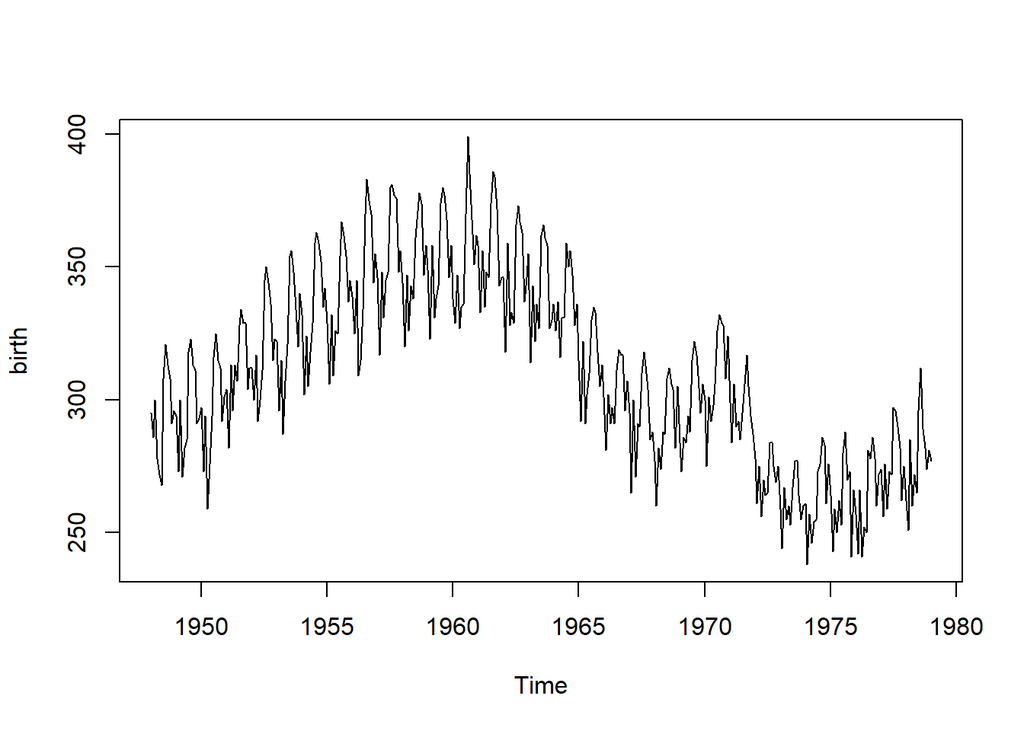

```r
plot(birth)
```

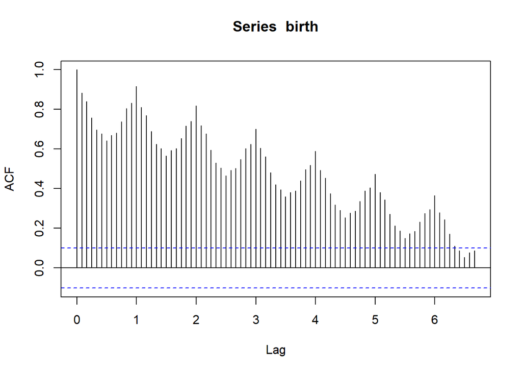

```r
# ACF, PACF
acf(birth, lag.max = 80)
```

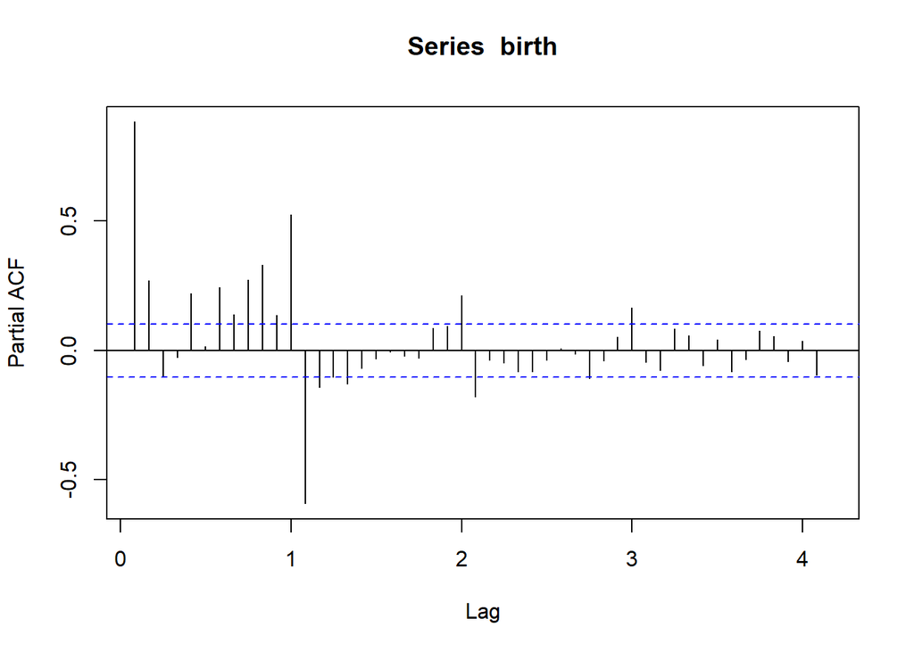

```r
pacf(birth, lag.max = 50)
```

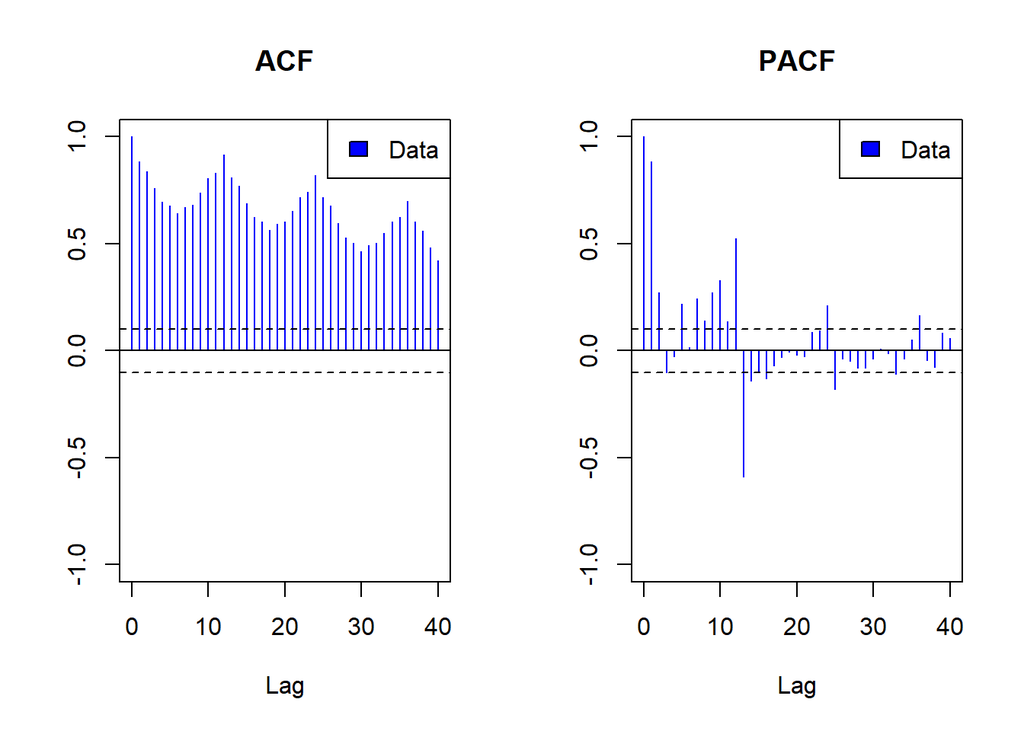

```r
plota(birth)
```

- There is an an upward trend at the begining, but it has a correction (downward trend) after 1960.
- There is seasonality of 12.
- It seems that there is no drastic variance changes.

## 2. Do a transformation and eliminate the trend and/or seasonal components, if applicable.

```r
# Variance change transformation
lambda = powerTransform(birth)
lambda$roundlam
```

```
birth
    1
```

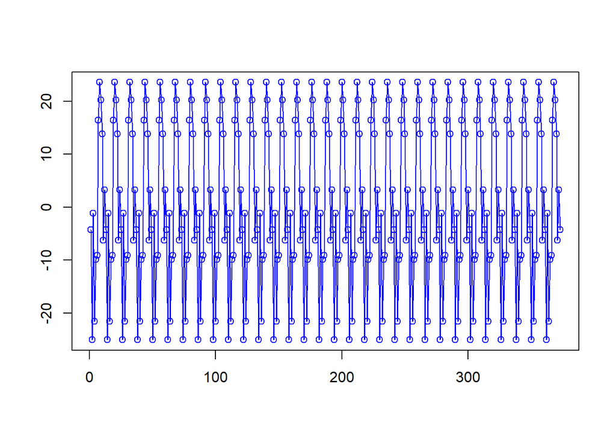

```r
# Seasonality
birth_season = season(birth, d=12)
plotc(birth_season)
```

Lambda is 1, then $\lambda$ = y. No transformation required. However, there is seasonality, d = 12.

## 3. Test IID hypothesis for the residuals R1.

```
Null hypothesis: Residuals are iid noise.
Test                        Distribution Statistic   p-value
Ljung-Box Q                Q ~ chisq(20)    133.65         0 *
McLeod-Li Q                Q ~ chisq(20)     67.86         0 *
Turning points T    (T-238.7)/8 ~ N(0,1)       224    0.0661
Diff signs S      (S-179.5)/5.5 ~ N(0,1)       178    0.7845
Rank P         (P-32310)/1140.8 ~ N(0,1)     31613    0.5412
```

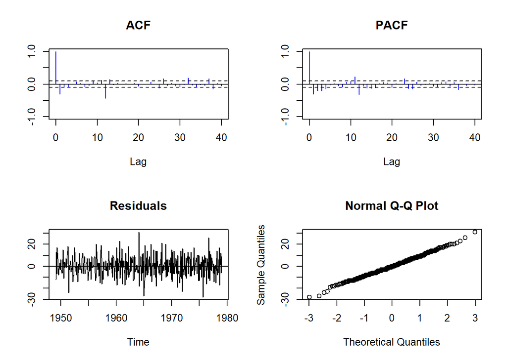

```r
# Differencing Operator
birth_diff = c("diff", 12, "diff", 1)

# IID hypothesis test
birth_r_diff = Resid(birth, birth_diff)
test(birth_r_diff)
```

- Reject the IID null hypothesis. The time series is not stationary.